# Epifanio, Giani, and Ivandic (2023)

> **Multiple-analysis note.** Each analysis in this report is estimated separately. The report does not pool events or outcomes, and its confidence intervals are not adjusted for multiple comparisons.

## Privacy rights

eventsurvey_summary(formula = mean ~ day, data = privacy, event_time = 0, window = 5, event_day = “include”, report_event_day = FALSE, schedule = “observed”)

### Main result

The estimated window-average event effect is **-0.150**. The honest 95% confidence interval is **[-1.438, 1.137]**. Effects are expressed in the original units of **mean**.

**Estimand-specific calibration.** Daily intervals use matching elapsed forecast horizons. The average effect and bias bound aggregate daily quantities after calibration. The average honest interval uses daily intervals at significance level `alpha / window` (Bonferroni) before averaging endpoints. The conventional standard error includes cross-day covariance from the shared pre-event fit. Displayed daily intervals are pointwise. Validity requires the daily population bias restrictions and sampling assumptions.

| Quantity | Value |
| --- | --- |
| Average effect | -0.150 |
| Standard error | 0.108 |
| Conventional interval | [-0.362, 0.062] |
| Bias bound | 0.623 |
| Honest interval | [-1.438, 1.137] |
| Reference windows | 6 |
| Daily reference contrasts | 30 |

### Automatic diagnostics

These checks describe features that may deserve attention. A “Review” status does not invalidate the analysis and does not change any estimate. Review is triggered by missing calendar periods, any observed period with fewer than 10 responses, pooled variance substitution, fewer than five rolling reference windows, or an observed-period window spanning more calendar time than requested.

| Check | Status | Detail | Recommendation |
| --- | --- | --- | --- |
| Calendar coverage | Review | 2 pre-event and 0 forecast calendar period(s) are unobserved. | Confirm that schedule = “observed” matches the intended design; outcomes are not interpolated. |
| Responses per period | Review | 101 of 137 observed periods have fewer than 10 responses; 24 have one response. | Inspect small-period means and interpret them cautiously. |
| Variance information | Review | 24 observed period(s) use the pooled within-period variance because their own variance is unavailable. | Review these periods; pooled variance is used automatically without creating outcomes. |
| Reference windows | OK | 6 rolling pre-event reference windows calibrate the bias bound. | No action needed. |
| Elapsed window spans | Review | A 5-period window spans as many as 6 fitting and 5 forecasting calendar periods. | Check whether the longer elapsed horizons remain substantively comparable. |

### Observed and counterfactual outcomes

The line extrapolates the fitted pre-event trend. Open points show the estimated no-event outcomes, and vertical gaps show period-specific effects. When covariates are included, the line averages the adjusted predictions in each period; it can bend as respondent composition changes despite the linear time term.

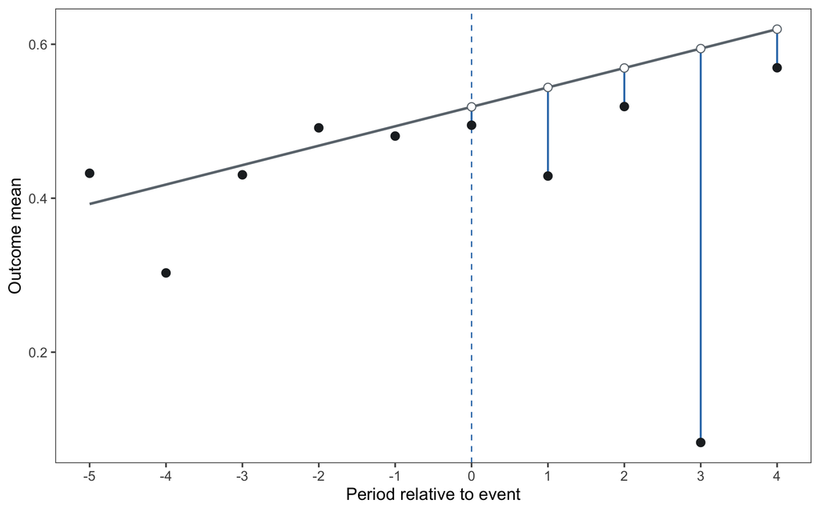

### Period-specific effects

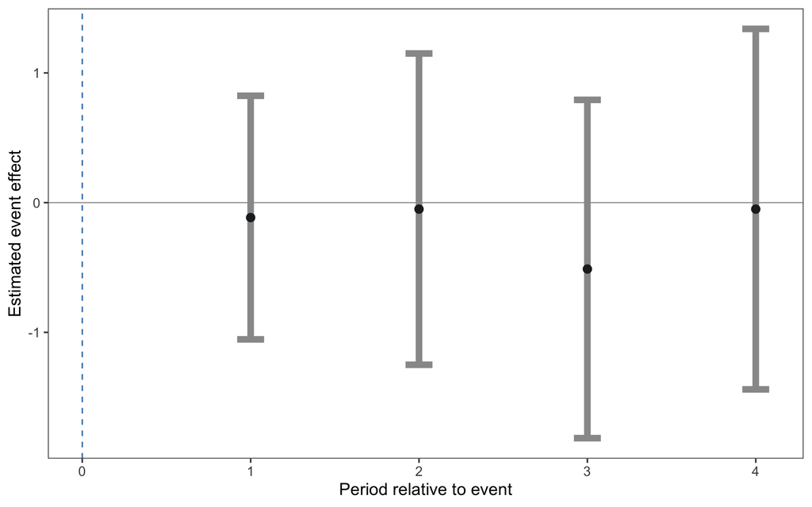

|  | relative_period | observed | counterfactual | effect | std_error | conf_low | conf_high | horizon | bias_bound | n_reference |
| --- | --- | --- | --- | --- | --- | --- | --- | --- | --- | --- |
| 2 | 1 | 0.429 | 0.544 | -0.115 | 0.089 | -1.054 | 0.824 | 2 | 0.523 | 6 |
| 3 | 2 | 0.519 | 0.569 | -0.050 | 0.122 | -1.250 | 1.150 | 3 | 0.719 | 6 |
| 4 | 3 | 0.083 | 0.594 | -0.512 | 0.241 | -1.816 | 0.792 | 4 | 0.639 | 6 |
| 5 | 4 | 0.570 | 0.620 | -0.050 | 0.148 | -1.440 | 1.339 | 5 | 0.780 | 6 |

### Forecast diagnostics

These are the individual rolling pre-event forecast errors. Calibration selects matching horizons separately for each day. Prediction errors are not averaged across days before calibration.

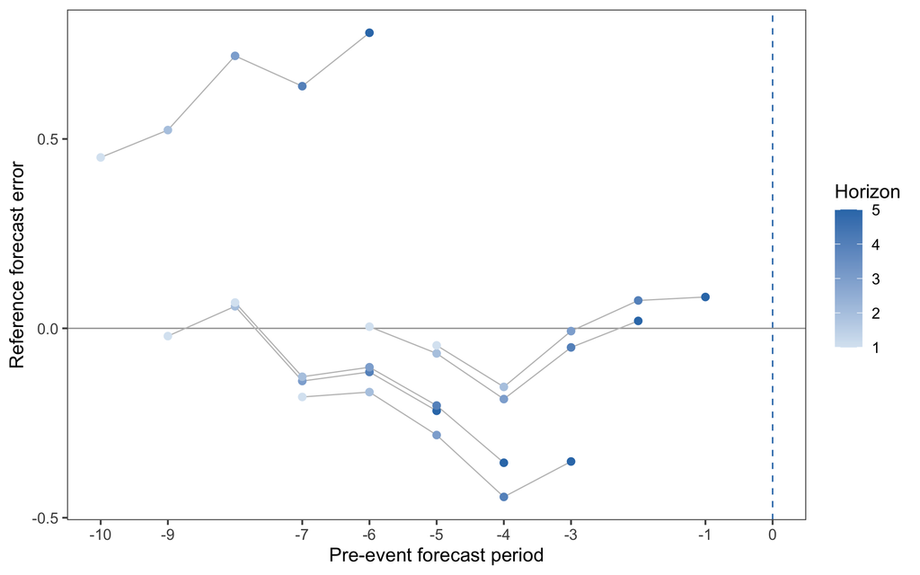

### Average components

All target days enter the average, including an included event day whose ordinary daily display was suppressed. These intervals use significance level `alpha / window`; averaging their endpoints gives the reported average honest interval.

| relative_period | observed | counterfactual | effect | std_error | conf_low | conf_high | horizon | bias_bound | n_reference |
| --- | --- | --- | --- | --- | --- | --- | --- | --- | --- |
| 0 | 0.495 | 0.519 | -0.024 | 0.068 | -0.947 | 0.899 | 1 | 0.451 | 6 |
| 1 | 0.429 | 0.544 | -0.115 | 0.089 | -1.185 | 0.955 | 2 | 0.523 | 6 |
| 2 | 0.519 | 0.569 | -0.050 | 0.122 | -1.401 | 1.301 | 3 | 0.719 | 6 |
| 3 | 0.083 | 0.594 | -0.512 | 0.241 | -2.024 | 1.001 | 4 | 0.639 | 6 |
| 4 | 0.570 | 0.620 | -0.050 | 0.148 | -1.631 | 1.531 | 5 | 0.780 | 6 |

### Survey coverage

The line and points show observed period means. The light-gray bars just above the x-axis show the relative number of responses in each period; the tallest bar is the period with the most responses.

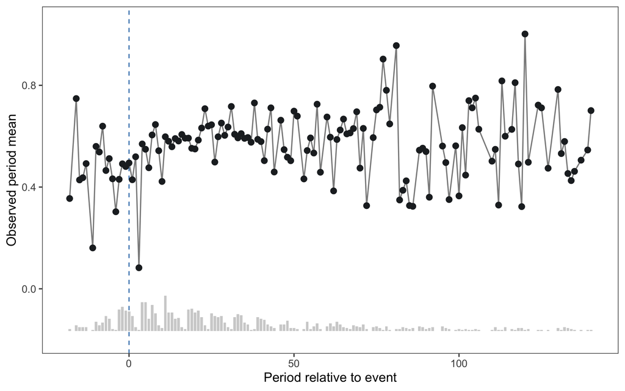

| Quantity | Value |
| --- | --- |
| Data level | Period summary |
| Input rows | 137 |
| Rows used | 137 |
| Rows omitted for missing outcome or time (or included covariates) | 0 |
| Total responses represented | 997 |
| Observed periods | 137 |
| Minimum responses per period | 1 |
| Median responses per period | 4 |
| Maximum responses per period | 38 |
| Missing pre-event periods | -17, -12 |
| Missing forecast periods | None |

### Analysis settings

| Setting | Value |
| --- | --- |
| Formula | mean ~ day |
| Event period | 0 |
| Event-period rule | include |
| Report event period | No |
| Fit and forecast window | 5 observed periods |
| Period schedule | observed |
| Calibration | estimand |
| Final fitting span | 5 periods on the time scale |
| Final forecast span | 5 periods on the time scale |
| Confidence level | 95% |
| Covariates | None |
| Uncertainty calculation | Analytic period-mean covariance |

### Interpretation limits

The estimate compares observed outcomes after the event with an extrapolation of the pre-event trend. A causal interpretation requires that, absent the event, this trend would have remained a credible short-run counterfactual. The analysis does not by itself rule out other contemporaneous changes or event-related changes in who responds to the survey. The honest interval accounts for sampling uncertainty and the package’s bounded forecast misspecification procedure; it does not make these design assumptions true. Covariates must be unaffected by the event. Adjusted effects concern each period’s respondent population and do not automatically identify an effect for a fixed population if composition changes. The uncertainty calculation assumes independent respondents; it does not cover clustered or repeated observations. Complete-case omission can also change the target population.

This analysis is estimated separately from the other analyses in this report; the report does not pool them and does not apply a multiple-comparison adjustment.

## Procedural rights

eventsurvey_summary(formula = mean ~ day, data = procedural, event_time = 0, window = 7, event_day = “include”, report_event_day = FALSE, schedule = “observed”)

### Main result

The estimated window-average event effect is **-0.091**. The honest 95% confidence interval is **[-1.222, 1.042]**. Effects are expressed in the original units of **mean**.

**Estimand-specific calibration.** Daily intervals use matching elapsed forecast horizons. The average effect and bias bound aggregate daily quantities after calibration. The average honest interval uses daily intervals at significance level `alpha / window` (Bonferroni) before averaging endpoints. The conventional standard error includes cross-day covariance from the shared pre-event fit. Displayed daily intervals are pointwise. Validity requires the daily population bias restrictions and sampling assumptions.

| Quantity | Value |
| --- | --- |
| Average effect | -0.091 |
| Standard error | 0.072 |
| Conventional interval | [-0.233, 0.050] |
| Bias bound | 0.286 |
| Honest interval | [-1.222, 1.042] |
| Reference windows | 4 |
| Daily reference contrasts | 28 |

### Automatic diagnostics

These checks describe features that may deserve attention. A “Review” status does not invalidate the analysis and does not change any estimate. Review is triggered by missing calendar periods, any observed period with fewer than 10 responses, pooled variance substitution, fewer than five rolling reference windows, or an observed-period window spanning more calendar time than requested.

| Check | Status | Detail | Recommendation |
| --- | --- | --- | --- |
| Calendar coverage | Review | 1 pre-event and 0 forecast calendar period(s) are unobserved. | Confirm that schedule = “observed” matches the intended design; outcomes are not interpolated. |
| Responses per period | Review | 100 of 137 observed periods have fewer than 10 responses; 25 have one response. | Inspect small-period means and interpret them cautiously. |
| Variance information | Review | 25 observed period(s) use the pooled within-period variance because their own variance is unavailable. | Review these periods; pooled variance is used automatically without creating outcomes. |
| Reference windows | Review | Only 4 rolling pre-event reference window(s) calibrate the bias bound. | Interpret the bound cautiously and use a longer pre-event series when available. |
| Elapsed window spans | Review | A 7-period window spans as many as 8 fitting and 7 forecasting calendar periods. | Check whether the longer elapsed horizons remain substantively comparable. |

### Observed and counterfactual outcomes

The line extrapolates the fitted pre-event trend. Open points show the estimated no-event outcomes, and vertical gaps show period-specific effects. When covariates are included, the line averages the adjusted predictions in each period; it can bend as respondent composition changes despite the linear time term.

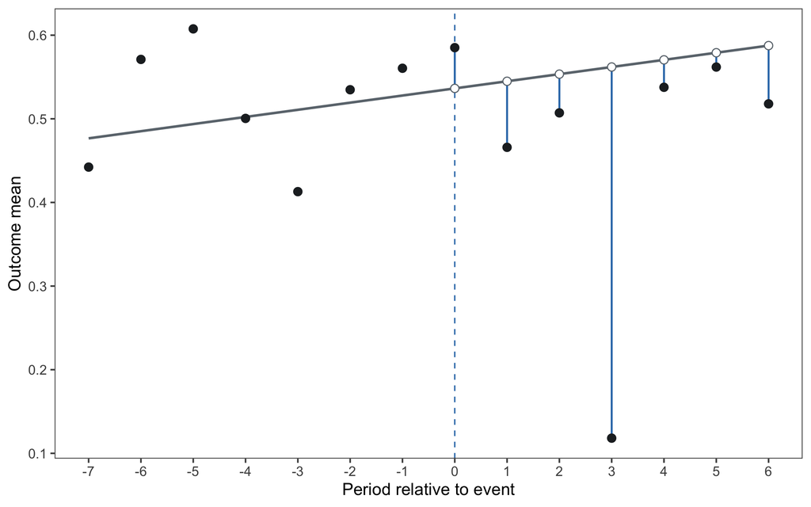

### Period-specific effects

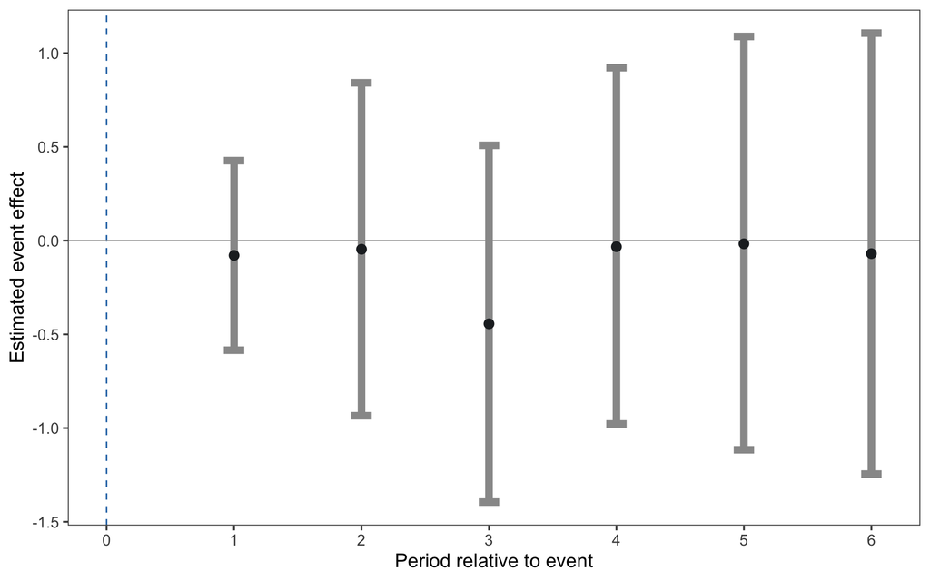

|  | relative_period | observed | counterfactual | effect | std_error | conf_low | conf_high | horizon | bias_bound | n_reference |
| --- | --- | --- | --- | --- | --- | --- | --- | --- | --- | --- |
| 2 | 1 | 0.466 | 0.545 | -0.079 | 0.072 | -0.584 | 0.426 | 2 | 0.162 | 4 |
| 3 | 2 | 0.507 | 0.553 | -0.046 | 0.096 | -0.934 | 0.842 | 3 | 0.293 | 4 |
| 4 | 3 | 0.118 | 0.562 | -0.444 | 0.236 | -1.395 | 0.508 | 4 | 0.274 | 4 |
| 5 | 4 | 0.538 | 0.570 | -0.033 | 0.085 | -0.978 | 0.922 | 5 | 0.402 | 4 |
| 6 | 5 | 0.562 | 0.579 | -0.017 | 0.085 | -1.116 | 1.089 | 6 | 0.320 | 4 |
| 7 | 6 | 0.518 | 0.588 | -0.070 | 0.107 | -1.245 | 1.107 | 7 | 0.335 | 4 |

### Forecast diagnostics

These are the individual rolling pre-event forecast errors. Calibration selects matching horizons separately for each day. Prediction errors are not averaged across days before calibration.

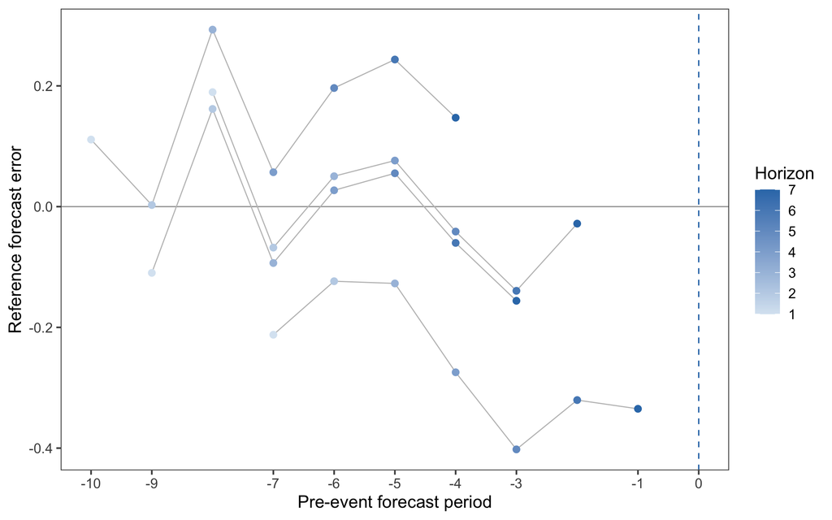

### Average components

All target days enter the average, including an included event day whose ordinary daily display was suppressed. These intervals use significance level `alpha / window`; averaging their endpoints gives the reported average honest interval.

| relative_period | observed | counterfactual | effect | std_error | conf_low | conf_high | horizon | bias_bound | n_reference |
| --- | --- | --- | --- | --- | --- | --- | --- | --- | --- |
| 0 | 0.585 | 0.536 | 0.049 | 0.062 | -0.656 | 0.754 | 1 | 0.212 | 4 |
| 1 | 0.466 | 0.545 | -0.079 | 0.072 | -0.772 | 0.614 | 2 | 0.162 | 4 |
| 2 | 0.507 | 0.553 | -0.046 | 0.096 | -1.156 | 1.063 | 3 | 0.293 | 4 |
| 3 | 0.118 | 0.562 | -0.444 | 0.236 | -1.647 | 0.761 | 4 | 0.274 | 4 |
| 4 | 0.538 | 0.570 | -0.033 | 0.085 | -1.257 | 1.205 | 5 | 0.402 | 4 |
| 5 | 0.562 | 0.579 | -0.017 | 0.085 | -1.434 | 1.410 | 6 | 0.320 | 4 |
| 6 | 0.518 | 0.588 | -0.070 | 0.107 | -1.628 | 1.490 | 7 | 0.335 | 4 |

### Survey coverage

The line and points show observed period means. The light-gray bars just above the x-axis show the relative number of responses in each period; the tallest bar is the period with the most responses.

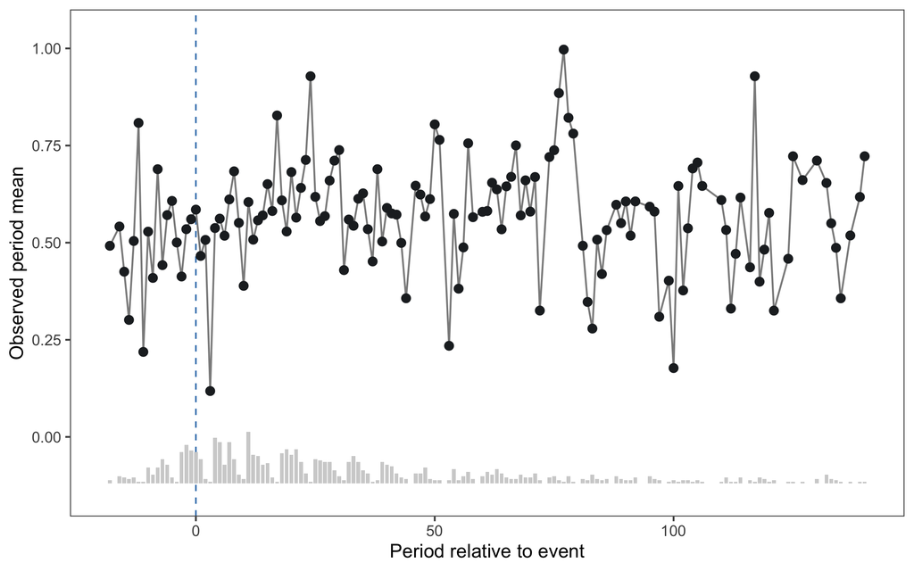

| Quantity | Value |
| --- | --- |
| Data level | Period summary |
| Input rows | 137 |
| Rows used | 137 |
| Rows omitted for missing outcome or time (or included covariates) | 0 |
| Total responses represented | 998 |
| Observed periods | 137 |
| Minimum responses per period | 1 |
| Median responses per period | 4 |
| Maximum responses per period | 36 |
| Missing pre-event periods | -17 |
| Missing forecast periods | None |

### Analysis settings

| Setting | Value |
| --- | --- |
| Formula | mean ~ day |
| Event period | 0 |
| Event-period rule | include |
| Report event period | No |
| Fit and forecast window | 7 observed periods |
| Period schedule | observed |
| Calibration | estimand |
| Final fitting span | 7 periods on the time scale |
| Final forecast span | 7 periods on the time scale |
| Confidence level | 95% |
| Covariates | None |
| Uncertainty calculation | Analytic period-mean covariance |

### Interpretation limits

The estimate compares observed outcomes after the event with an extrapolation of the pre-event trend. A causal interpretation requires that, absent the event, this trend would have remained a credible short-run counterfactual. The analysis does not by itself rule out other contemporaneous changes or event-related changes in who responds to the survey. The honest interval accounts for sampling uncertainty and the package’s bounded forecast misspecification procedure; it does not make these design assumptions true. Covariates must be unaffected by the event. Adjusted effects concern each period’s respondent population and do not automatically identify an effect for a fixed population if composition changes. The uncertainty calculation assumes independent respondents; it does not cover clustered or repeated observations. Complete-case omission can also change the target population.

This analysis is estimated separately from the other analyses in this report; the report does not pool them and does not apply a multiple-comparison adjustment.

## Reproducibility

| Item | Value |
| --- | --- |
| eventsurvey version | 0.4.1 |
| R version | R version 4.6.1 (2026-06-24) |
| Generated | 2026-10-24 10:20 EDT |